# Minnesota Statewide Aquatic Plants and Associated Data

Mike Verhoeven

2022-09-16

```r
# load libraries ------------------------------------------------------------------
```

### Libraries

```r
  library(data.table)
    update_dev_pkg()# remotes::install_github("Rdatatable/data.table")
```

```
## R data.table package is up-to-date at c4a2085e35689a108d67dacb2f8261e4964d7e12 (1.14.3)
```

```r
  library(ggplot2)
  library(stringr)
  library(sf)
  library(vegan)
  library(gridExtra)
  library(dplyr)
  library(tidyr)
  library(janitor)
  # library(lme4)
  # library(sjPlot)
  library(mediation)
  library(ggpubr)
  # library(EnvStats)
  # library(lmerTest)
  # library(merTools)
  # library(rstanarm)
  library(ggsn)
# load in functions -------------------------------------------------------
```

### Functions

```r
  f_dowle3natozeros = function(DT, x) {
  # or by number (slightly faster than by name) :
  for (j in x)
    set(DT,which(is.na(DT[[j]])),j,"0")
}


# load in data -------------------------------------------------
```

### Data

The plants observations data and collaborator corrections are datasets that we have generated.

Secchi data have been aggregated from public sources by Kelsey Vitense.

Hydrography (https://gisdata.mn.gov/dataset/water-dnr-hydrography; 5April2022) and watershed (https://gisdata.mn.gov/dataset/geos-dnr-watersheds; 10Aug2022) data were retrieved from the MN geospatial commons.

Species statuses were retrieved from the MN DNR (https://www.dnr.state.mn.us/eco/mcbs/plant_lists.html; 5April2022).

```r
  #plants observation dataset:
  plants <- fread(input = "data&scripts/data/input/plant_surveys_mn.csv", drop = 1:2) #import, dropping the exported row numbers

  #collaborator corrections and feedback:
  coll_edits <- fread(input = "data&scripts/data/input/Edited_post_contrib_feedback.csv")

  #secchi data:
  secchi <- fread(input = "data&scripts/data/input/AllSecchi_plus_ShallowLakesSecchi.csv") #import, dropping the exported row numbers

  #hydrography & watersheds
  pwi_l <- st_read(dsn = "data&scripts/data/input/shp_water_dnr_hydrography", layer = "dnr_hydro_features_all")
  watersheds_huc8 <- st_read(dsn = "data&scripts/data/input/shp_geos_dnr_watersheds", layer = "dnr_watersheds_dnr_level_04_huc_08_majors")
  #species statuses
  rte <- fread(input = "data&scripts/data/input/2013_dnr_plant_checklist_web.csv")



# collaborator corrections ------------------------------------------------
```

## Collaborator Corrections

This section uses the collaborator feedback to revise the dataset.

```r
  # check survey ID alignment
  #sum(!coll_edits[, SURVEY_ID, ] %in% plants[ , SURVEY_ID]) #100% of collaborator input has a match in plants
  names(coll_edits)[1] <- "feedback"
  coll_edits[ , .N , feedback ]
```

```
##                                                         feedback     N
##                                                           <char> <int>
##  1:                             curlyleaf pondweed survey delete    23
##  2:                                               data available     9
##  3:                                       delete erroneous entry     1
##  4:                                             duplicate delete     6
##  5:                                           errors from import     2
##  6:                                             missing metadata     2
##  7:                                            no data available    92
##  8:                 Point 69 has Lmin entered as 5 - change to 2     1
##  9:                                  rake density data available     1
## 10: reimport required - contact kchamberlin@minneapolisparks.org     2
## 11:                                             unuseable delete   683
## 12:                                        useable data reimport   149
## 13:                                                               1853
```

```r
  # deletions
  # coll_edits[ str_detect(feedback, "delete",), SURVEY_ID ,    ]#which are marked for deletion?
  plants <- plants[  !SURVEY_ID %in%
                       coll_edits[ str_detect(feedback, "delete",), SURVEY_ID ,    ]#this drops about 10k observations from the dataset
                     , , ]

  # tag for reimport
  # these surveys need to be reimported and any current data deleted. We have these data in our files.

  # coll_edits[str_detect(feedback, "import",) , SURVEY_ID  , ]
  # plants[ SURVEY_ID %in% coll_edits[str_detect(feedback, "import",) , SURVEY_ID  , ], .N ,  SURVEY_ID]
  sel <- plants[ SURVEY_ID %in% coll_edits[str_detect(feedback, "import",) , SURVEY_ID  , ],  ,  ] #peel off those reimport data
  sel <- sel[!duplicated(sel[ , SURVEY_ID , ]),] #compress to one row where botched import produced some data
  # plants[ SURVEY_ID %in% coll_edits[str_detect(feedback, "import",) , SURVEY_ID  , ], .N ,  SURVEY_ID]

  # drop or modify some cols to reflect bad import
  sel[ , c("STA_NBR_DATASOURCE", "DEPTH_FT", "NO_VEG_FOUND", "REL_ABUND", "WHOLE_RAKE_REL_ABUND","SUBSTRATE", "SURVEYOR", "TAXON", "SAMPLE_NOTES", "SURFACE_GROWTH", "POINT_LVL_SECCHI", "X", "Y", "NORTHING", "EASTING", "LATITUDE", "LONGITUDE", "UTMX", "UTMY", "POINT_ID", "OBS_ID") := NA ,]#in sel, dump these columns
  sel[ , INDATABASE := FALSE]#mark these as not in database
  plants <- plants[  !SURVEY_ID %in% coll_edits[str_detect(feedback, "import",) , SURVEY_ID  , ],  ,  ] #drops ~900 obs
  plants <- rbind(plants, sel)
  plants[ SURVEY_ID %in% sel[, SURVEY_ID] , SURVEY_FEEDBACK := "reimport required" , ]

  # data available from collaborator
  # coll_edits[ feedback %in% c("data available", "missing metadata") , SURVEY_ID , ]
  plants[ SURVEY_ID %in% coll_edits[ feedback %in% c("data available", "missing metadata") , SURVEY_ID , ]  , SURVEY_FEEDBACK := "data available from collaborator" ,   ]
  plants[ SURVEY_ID %in% coll_edits[ feedback %in% c("rake density data available") , SURVEY_ID , ]  , SURVEY_FEEDBACK := "rake density data available from collaborator" ,   ]


  # no data available
  plants[ SURVEY_ID %in% coll_edits[ feedback %in% c("no data available") , SURVEY_ID , ]  , SURVEY_FEEDBACK := "no data available" ,   ]
  nrow(plants[SURVEY_FEEDBACK == "no data available" , .N , SURVEY_ID] )# how many cases with data unavailable/ not known where raw data are?
```

```
## [1] 92
```

```r
  # one-offs
  # coll_edits[feedback == "Point 69 has Lmin entered as 5 - change to 2", SURVEY_ID]
  plants[SURVEY_ID == coll_edits[feedback == "Point 69 has Lmin entered as 5 - change to 2", SURVEY_ID] &
           STA_NBR_DATASOURCE == 69 &
           REL_ABUND == 5,
         REL_ABUND := 2]

  # Taxa naming problem:
  plants[TAXON == "Mitellopsis", TAXON := "Nitellopsis"]


  # preferred datasource name
  # coll_edits[ , .N , EDIT_DATASOURCE]
  plants[ , SURVEY_DATASOURCE := coll_edits[match(plants$DATASOURCE, coll_edits$DATASOURCE),  EDIT_DATASOURCE ] ,  ]
  # plants[ , .N ,  SURVEY_DATASOURCE]
  # plants[SURVEY_DATASOURCE == "", .N , DATASOURCE ]
  plants[DATASOURCE == "DNR Lakes and Rivers", SURVEY_DATASOURCE := "DNR Lakes and Rivers"]
  plants[DATASOURCE == "DNR Fisheries", SURVEY_DATASOURCE := "DNR Fisheries"]
  plants[DATASOURCE == "Rantala TIP", SURVEY_DATASOURCE := "DNR Fisheries"]
  plants[DATASOURCE == "Muthukrishnan Et al", SURVEY_DATASOURCE := "DNR Shallow Lakes" , ]
  plants[SURVEY_DATASOURCE == "DNR Fisheries Research" , SURVEY_DATASOURCE := "DNR Fisheries"]

  # check contribution # of surveys by new named datasources
  plants[ , length(unique(SURVEY_ID)) , SURVEY_DATASOURCE ]
```

```
##                              SURVEY_DATASOURCE    V1
##                                         <char> <int>
##  1:                          DNR Shallow Lakes  1666
##  2:             Freshwater Scientific Services   200
##  3:         Newman Lab University of Minnesota   115
##  4:         Minnehaha Creek Watershed District   111
##  5:                              DNR Fisheries   264
##  6:               DNR Invasive Species Program   352
##  7:                       DNR Lakes and Rivers   268
##  8:                         Blue Water Science   110
##  9:        Minneapolis Park & Recreation Board    10
## 10:          Endangered Resource Services, LLC     7
## 11:                           Barr Engineering    85
## 12:                 Three Rivers Park District    63
## 13:                    AIS Consulting Services    13
## 14:                              Ramsey County    91
## 15: Ramsey-Washington Metro Watershed District    30
## 16:          Capitol Region Watershed District    60
## 17:           Emmons & Olivier Resources, Inc.     8
```

```r
  # lake name corrections
  plants[ , NEW_LAKE_NAME := coll_edits[match(plants$SURVEY_ID, coll_edits$SURVEY_ID),  EDIT_LAKE_NAME ] ,  ]
  plants[NEW_LAKE_NAME %in% c("lake of the isles", "clear", "bde maka ska"), LAKE_NAME := NEW_LAKE_NAME ]
  plants[ , NEW_LAKE_NAME := NULL ,]


  # surveyor corrections
  plants[ , NEW_SURVEYOR := coll_edits[match(plants$SURVEY_ID, coll_edits$SURVEY_ID),  EDIT_SURVEYOR ] ,  ]
  # plants[, .N, NEW_SURVEYOR ]
  plants[!NEW_SURVEYOR == "" & !is.na(NEW_SURVEYOR), SURVEYOR := NEW_SURVEYOR , ]
  plants[ , NEW_SURVEYOR := NULL ,]


  # date corrections
  plants[ , NEW_DATE := coll_edits[match(plants$SURVEY_ID, coll_edits$SURVEY_ID),  EDIT_DATE ] ,  ]
  # plants[, .N, NEW_DATE ]
  # plants[!NEW_DATE == "" & !is.na(NEW_DATE), .N , NEW_DATE ]
  plants[!NEW_DATE == "" & !is.na(NEW_DATE) , SURVEY_DATE := as.Date(NEW_DATE, format = "%d%b%Y") ,]
  plants[ , NEW_DATE := NULL ,]


  # input rake density scales
  #overwrite any bad rake scales:
  coll_edits[!is.na(`EDITED_SCALE_RAKE_DENS (0-X)`) , `SCALE_RAKE_DENS (0-X)` := `EDITED_SCALE_RAKE_DENS (0-X)`  ]
  # coll_edits[ ,.N , `SCALE_RAKE_DENS (0-X)`  ]
  coll_edits[ `SCALE_RAKE_DENS (0-X)` %in% c(1,2) , `SCALE_RAKE_DENS (0-X)` := NA  ]# these aren't real abundance scales--they should be marked as NA, to indicate only pres-abs data are useable.

  #push over to plants DB:
  plants[ , RAKE_SCALE_USED := coll_edits[match(plants$SURVEY_ID, coll_edits$SURVEY_ID),  `SCALE_RAKE_DENS (0-X)` ] ,  ]


  # for these surveys, we can see that our collaborators inputs on rake scale was not correct:
  plants[REL_ABUND>RAKE_SCALE_USED, .N , .(SURVEY_ID)  ]
```

```
##    SURVEY_ID     N
##        <int> <int>
## 1:      1418    48
## 2:      3128     1
```

```r
  #two more left now to manually change to max scale observed rather than reported:
  plants[SURVEY_ID == 1418 , RAKE_SCALE_USED := 5]
  plants[SURVEY_ID == 3128 , RAKE_SCALE_USED := 5]

  # check process:
  plants[ , .("max_observed_in_data" = max(REL_ABUND, na.rm = T)) , RAKE_SCALE_USED]
```

```
##    RAKE_SCALE_USED max_observed_in_data
##              <int>                <int>
## 1:              NA                    2
## 2:               4                    4
## 3:               5                    5
## 4:               3                    3
```

```r
  # clean up WS
  rm(coll_edits, sel)


# georeference data -------------------------------------------------------
```

## Georeference Data

This section uses MN hydrography geodata to add direct geodata into the dataset. After run, pwi_l and plants can be linked on the shared “order_ID” column, and HUC-8 level watersheds are included in the dataset

```r
  # merge geospatial files
  #change sf data.frame to a data.table
  setDT(pwi_l)

  # linking plants db to spatial reference:
  #shapefile dows need to be made numeric (drops leading zeros)
  # pwi_l[ , dowlknum , ]
  pwi_l[ , dow_main := round(as.numeric(dowlknum)/100,0)*100 , ]

  #there's a lot of junk in there, work towards a 1:1 of plants dows and pwi_l dows
  pwi_l <- pwi_l[!is.na(dowlknum)]# drops many polygons that aren't lakes (islands, rivers, etc)
  pwi_l[  , order_ID:= .I , ]#adds a key
  #drop non-mn shapes
  pwi_l <- pwi_l[!outside_mn == "Y"]
  #which dows are duplicated in the shapes?
  pwi_l[pwi_l[, duplicated(dowlknum),], dowlknum]
```

```
##  [1] "32005700" "66001400" "34002800" "43011500" "86017800" "70001600"
##  [7] "27000300" "02000500" "86025202" "86025202" "73008200" "75002400"
## [13] "78002400" "56097900" "56078100" "18039400" "18014500" "09003900"
## [19] "18026900" "18031100" "03007700" "03011200" "56164900" "03030400"
## [25] "03037402" "56078600" "60021700" "60017800" "60021700" "04029700"
## [31] "31090300" "31090300" "69058000" "69000300" "16063300" "69034500"
```

```r
  #lets review those data and see if we can devise any cleaning ideas
  #pwi_l[dowlknum %in% pwi_l[pwi_l[, duplicated(dowlknum),], dowlknum],]
  # we can just use the first instance of these duplicated waterbodies:
  # we'll do that by dropping the subsequent duplicates!
  pwi_l <- pwi_l[!pwi_l[, duplicated(dowlknum),], , ]

  # missing matches in the plants data to shapefile dows
  sum(is.na(match(plants[ , unique(DOW) ,], unique(pwi_l[ , dowlknum , ]))))
```

```
## [1] 220
```

```r
  # missing matches in the plants data to shapefile mainlake dows
  sum(is.na(match(plants[ , unique(DOW) ,], unique(pwi_l[ , dow_main , ]))))
```

```
## [1] 47
```

```r
  #append a polygon value to the plants data (here we'll use our order_ID from above)
  plants[ , order_ID := pwi_l[ match( plants[ , DOW ,], pwi_l[ , as.numeric(dow_main) , ]) , order_ID , ]  ]

  #and any that didn't match on that, try the basin specific
  plants[ is.na(order_ID) , order_ID := pwi_l[ match(plants[ is.na(order_ID) , DOW ,], pwi_l[ , as.numeric(dowlknum) , ]), order_ID , ]  ]

  # now to navigate these last non-compliant ones...
  plants[is.na(order_ID) & !is.na(DOW), .N ,  .(LAKE_NAME, DOW, DATASOURCE)]
```

```
##                LAKE_NAME      DOW          DATASOURCE     N
##                   <char>    <int>              <char> <int>
## 1:           sakatah bay 40000201      Allison Gamble   934
## 2: rrwma - pool 1 - east 68000501 Muthukrishnan Et al    74
## 3: rrwma - pool 1 - west 68000502 Muthukrishnan Et al    94
## 4: katherine abbott pond 82009999       Meg Rattei_19    36
## 5:               mcmahon 70050000         april londo     3
```

```r
  pwi_l[ dowlknum == "40000200", order_ID]
```

```
## [1] 1267
```

```r
  plants[ DOW == 40000201, order_ID := pwi_l[ dowlknum == "40000200", order_ID] ] #Upper Sakatah polygon

  pwi_l[ dowlknum == "68000500", order_ID]
```

```
## [1] 26678
```

```r
  plants[ DOW %in% c(68000501,68000502), order_ID := pwi_l[ dowlknum == "68000500", order_ID] ] #Roseau River WMA

  pwi_l[ dowlknum == "70005000", order_ID]
```

```
## [1] 5481
```

```r
  plants[ DOW == 70050000, order_ID := pwi_l[ dowlknum == "70005000", order_ID] ] #Carls Lake

  pwi_l[ dowlknum == "82011800", order_ID]
```

```
## [1] 7235
```

```r
  plants[ DOW == 82009999, order_ID := pwi_l[ dowlknum == "82011800", order_ID] ] #Katherine Abbott Pond

  # the plants datset lakes with no geodata in the hydrography layer we used:
  plants[is.na(order_ID) , .N ,  .(LAKE_NAME, DOW, DATASOURCE)]
```

```
##                                     LAKE_NAME   DOW          DATASOURCE     N
##                                        <char> <int>              <char> <int>
##  1:                                    pool 2    NA Muthukrishnan Et al    97
##  2:                               reynen pond    NA Muthukrishnan Et al    46
##  3:                        unnamed delong wpa    NA Muthukrishnan Et al    22
##  4:                                   big sob    NA          Jill Sweet    64
##  5:                    ivanhoe wma east basin    NA Muthukrishnan Et al    26
##  6:                                olson pool    NA Muthukrishnan Et al   104
##  7: goldmine slough section - vermilion river    NA Muthukrishnan Et al   215
##  8: vermilion falls section - vermilion river    NA Muthukrishnan Et al    88
##  9:                                gull river    NA Muthukrishnan Et al   336
## 10:                         mississippi river    NA Muthukrishnan Et al  1769
## 11:                            little elk wma    NA Muthukrishnan Et al    98
## 12:                                   unnamed    NA Muthukrishnan Et al    20
## 13:                          sand prairie wma    NA Muthukrishnan Et al    75
## 14:                    loerch wma impoundment    NA Muthukrishnan Et al    31
## 15:             daggett brook wma impoundment    NA Muthukrishnan Et al   109
## 16:                               sterle pool    NA Muthukrishnan Et al   175
## 17:                              trettle pool    NA Muthukrishnan Et al   328
## 18:                              dundee marsh    NA Muthukrishnan Et al     8
```

```r
  # in total, this is 18 surveys and 3611 observations without ANY geolocation
  plants[, summary(order_ID)]
```

```
##    Min. 1st Qu.  Median    Mean 3rd Qu.    Max.    NA's
##      13    7242   15394   13182   17484   26778    3611
```

```r
  # fix up local geospatial info
  #check for weird X,Y vals in th UTM-looking columns
  plants[!is.na("X"), summary(X) ,]
```

```
##     Min.  1st Qu.   Median     Mean  3rd Qu.     Max.     NA's
##     45.1 341123.0 495722.0 464619.0 564792.0 598930.0  1274596
```

```r
  plants[!is.na("Y"), summary(Y) ,]
```

```
##    Min. 1st Qu.  Median    Mean 3rd Qu.    Max.    NA's
##     -93  166689 4909613 2728113 5084488 5184300 1271711
```

```r
  #some are clearly lat/longs
  plants[X < 4600, X ,]
```

```
##  [1] 45.09664 45.09664 45.09664 45.09664 45.09664 45.09664 45.09664 45.09664
##  [9] 45.09664 45.09664 45.09664 45.09727 45.09727 45.09727 45.09727 45.09727
```

```r
  plants[X < 4600, LATITUDE := X ,]
  plants[X < 4600, X := NA ,]

  plants[Y<10000, summary(Y) ,]
```

```
##    Min. 1st Qu.  Median    Mean 3rd Qu.    Max.
##  -93.07   44.90   44.91   43.39   44.98   45.00
```

```r
  plants[Y<10000 & Y>0,  LATITUDE := Y ,]
  plants[Y<10000 & Y>0,  Y := NA ,]

  plants[Y<10000, LONGITUDE := Y  ,]
  plants[Y<10000, Y := NA  ,]

  #whatever the heck is leftover here is weeeeeird and muddled.
  plants[!is.na("X"), summary(X) ,]
```

```
##    Min. 1st Qu.  Median    Mean 3rd Qu.    Max.    NA's
##  237606  341171  495725  466695  564792  598930 1274612
```

```r
  plants[!is.na("Y"), summary(Y) ,]
```

```
##    Min. 1st Qu.  Median    Mean 3rd Qu.    Max.    NA's
##  140723  210010 5003604 3499077 5086243 5184300 1273139
```

```r
  # we need to delete these non-UTM vals form X & Y
  # plants[Y<4800000, .N, DATASOURCE ]
  plants[ Y < 4800000, c("X","Y") := NA,  ]

  #looks clean, now move into the UTM slots?
  plants[!is.na(UTMY) , summary(UTMY) ,]
```

```
##    Min. 1st Qu.  Median    Mean 3rd Qu.    Max.
## 4828777 5107493 5174364 5149917 5217742 5339053
```

```r
  plants[!is.na(UTMX) , summary(UTMX) ,]
```

```
##    Min. 1st Qu.  Median    Mean 3rd Qu.    Max.
##  229942  384600  408474  415722  442837  712374
```

```r
  #any conflicts with UTM loc data?
  plants[!is.na(UTMX) & !is.na(X)]
```

```
## Empty data.table (0 rows and 49 cols): SURVEY_ID,LAKE_NAME,DATASOURCE,SURVEY_DATE,STA_NBR_DATASOURCE,DEPTH_FT...
```

```r
  plants[!is.na(UTMY) & !is.na(Y)]
```

```
## Empty data.table (0 rows and 49 cols): SURVEY_ID,LAKE_NAME,DATASOURCE,SURVEY_DATE,STA_NBR_DATASOURCE,DEPTH_FT...
```

```r
  #move X, Y to UTMs
  plants[!is.na(X) , UTMX := X ,  ]
  plants[!is.na(Y) , UTMY := Y ,  ]

  plants[ , c("X", "Y") := NULL , ]


  #now Northing Easting, which happen to look like clean UTM data
  plants[!is.na(NORTHING), summary(NORTHING) ,]
```

```
##    Min. 1st Qu.  Median    Mean 3rd Qu.    Max.
## 4860888 5003560 5136308 5089221 5203396 5208310
```

```r
  plants[!is.na(EASTING), summary(EASTING) ,]
```

```
##    Min. 1st Qu.  Median    Mean 3rd Qu.    Max.
##  315321  339882  401439  413157  455109  515302
```

```r
  #overlap/ conflict?
  plants[!is.na(UTMX) & !is.na(NORTHING)]
```

```
## Empty data.table (0 rows and 47 cols): SURVEY_ID,LAKE_NAME,DATASOURCE,SURVEY_DATE,STA_NBR_DATASOURCE,DEPTH_FT...
```

```r
  plants[!is.na(UTMY) & !is.na(EASTING)]
```

```
## Empty data.table (0 rows and 47 cols): SURVEY_ID,LAKE_NAME,DATASOURCE,SURVEY_DATE,STA_NBR_DATASOURCE,DEPTH_FT...
```

```r
  #move Northing and easting to UTMs
  plants[!is.na(NORTHING), UTMY := NORTHING  ,]
  plants[!is.na(EASTING), UTMX := EASTING  ,]

  plants[ , c("NORTHING", "EASTING") := NULL , ]

  #now get all into same CRS:
  #conflicts?
  plants[!is.na(UTMX) & !is.na(LONGITUDE)]
```

```
## Empty data.table (0 rows and 45 cols): SURVEY_ID,LAKE_NAME,DATASOURCE,SURVEY_DATE,STA_NBR_DATASOURCE,DEPTH_FT...
```

```r
  plants[!is.na(UTMY) & !is.na(LATITUDE)]
```

```
## Empty data.table (0 rows and 45 cols): SURVEY_ID,LAKE_NAME,DATASOURCE,SURVEY_DATE,STA_NBR_DATASOURCE,DEPTH_FT...
```

```r
  #here we'll split into a non, UTM, and LL georef set, then convert ref'd to sf objects, then merge all back together
  # plants complete x,y in one CRS or another? NOPE... Oh well. moving on.
  # plants[!is.na(UTMX) & is.na(UTMY)]
  # # plants[]
  #
  # plants[!is.na(LATITUDE) & is.na(LONGITUDE)]
  # plants[is.na(LATITUDE) & !is.na(LONGITUDE)]

  #Conversion of data frame to sf object (note we've assumed NAD1983, Z15N for UTMs)
  plants_UTMS <- st_as_sf(x = plants[!is.na(UTMX)],
                          coords = c("UTMX", "UTMY"),
                          crs = "+proj=utm +zone=15")

  #Projection transformation
  plants_U_LL = st_transform(plants_UTMS, crs = "+proj=longlat +datum=WGS84")

  setDT(plants_U_LL)

  #Conversion of data frame to sf object
  plants_LLS <- st_as_sf(x = plants[!is.na(LONGITUDE)],
                         coords = c("LONGITUDE", "LATITUDE"),
                         crs = "+proj=longlat +datum=WGS84")

  setDT(plants_LLS)

  #drop unusedCRS cols from each:
  plants_U_LL[ , c("LATITUDE", "LONGITUDE") := NULL , ]
  plants_LLS[ , c("UTMX","UTMY") := NULL, ]

  plants2 <- rbindlist(list(plants_LLS, plants_U_LL))

  plants2 <- cbind(plants2, st_coordinates(st_as_sf(plants2)))

  plants2[ , geometry := NULL ,]

  names(plants2)[names(plants2)%in% c("X","Y")] <- c("Longitude","Latitude")

  #merge back to plants (check dims to ensure no duplications or overlaps):
  dim(plants)
```

```
## [1] 1278192      45
```

```r
  plants[is.na(UTMX) & is.na(LONGITUDE) , .N , ]+
    plants2[ , .N ,]
```

```
## [1] 1278192
```

```r
  plants1 <- plants[is.na(UTMX) & is.na(LONGITUDE), ]

  plants1[ , c("UTMX", "UTMY", "LATITUDE", "LONGITUDE") := NULL ,]

  plants1[ , c("Longitude", "Latitude") := NA, ]

  nrow(plants1)+nrow(plants2)
```

```
## [1] 1278192
```

```r
  plants <- rbindlist(list(plants1, plants2))

  rm(plants_LLS,plants_U_LL, plants1, plants2)

  # label all pwi_l with watershed names

  # st_join(pwi_l, watersheds_huc8)
  #
  # st_crs(plants_UTMS) <- st_crs(watersheds_huc8)
  #
  # plantsUTMS <- st_join(plants_UTMS, left = TRUE, watersheds_huc8)

  pwi_l <- st_sf(pwi_l)
  st_crs(pwi_l) <- st_crs(watersheds_huc8) #ignore warning, no re-projection needed in this case, we do this because I lost the crs in some of my data manipulation
  pwi_l <- st_join(pwi_l, left = TRUE, watersheds_huc8)
  setDT(pwi_l)
  rm(plants_pts, plants_UTMS)
# rake scale normalization -------------------------------------------
```

## Rake Abundance Normalization

This code will clean the relative rake density data from the whole PI dataset, shifting all to a 0,1,2,3 scale. This code was developed in the surveycollation project, but is implemented here (post-collaborator feedback) to allow the collabs to specify what the rake scale they used was.

```r
  #drop surveys with max vals of 1s and 1-2s
  rakes1 <- plants[RAKE_SCALE_USED %in% c(3,4,5), ]
  # rakes1[ , .N , REL_ABUND]
  #how many surveys in these categories?
  # rakes1[  , .N  , SURVEY_ID] #982

  #Now shift/ realign data per discussion above
    #1-4 survey shifted to 1-3
  rakes1[RAKE_SCALE_USED == 4 & REL_ABUND == 3 ,
         REL_ABUND := 2 ]
  rakes1[RAKE_SCALE_USED == 4 & REL_ABUND == 4 ,
         REL_ABUND := 3 ]
    #1-5 surveys shifted to 1-3
  rakes1[RAKE_SCALE_USED == 5 & (REL_ABUND == 3 |REL_ABUND == 4) ,
         REL_ABUND := 2 ]
  rakes1[RAKE_SCALE_USED == 5 & REL_ABUND == 5 ,
         REL_ABUND := 3 ]


  # #check that the max vals are all 3's
  # hist(rakes1[ !is.na(REL_ABUND) , max(REL_ABUND) , SURVEY_ID  ][,V1])
  #
  # #and all data are distributed in 1-3 rake density framework
  # hist(rakes1[ !is.na(REL_ABUND) , REL_ABUND ,  ])
  #
  # # count the number of surveys we've got
  # rakes1[ , .N , SURVEY_ID ] # N points per survey (includes NA's--points where no species were observed)


  # put the corrected rake scales back into the plants db
  # plants[ , , ]
  # rakes1[ , .N , OBS_ID][N>1]

  # rakes1[is.na(OBS_ID) , ,]

  #where people told us the rake scale but data to-date not in db:
  rakes1 <- rakes1[!is.na(OBS_ID)]

  #pop these corrected rake scale data into the plants dataset
  plants[OBS_ID %in% rakes1$OBS_ID , REL_ABUND_CORRECTED := rakes1$REL_ABUND  , ]

  #clean out intermediates
  rm(rakes1)

# add in secchi data ------------------------------------------------------
```

## Secchi Data Join

This code will conduct an eval of the fuzzy join of Secchi to plants data, calculate Secchi metrics based on the chosen fuzzy join, then excute the join. The code includes a solution adapted from a script written by Dan Larkin for the niches project (https://conservancy.umn.edu/handle/11299/218009).

Assign a Secchi to each observation based either via:

1. use the closest Secchi temporally (currently active code)
2. use an averaging method to grab close Secchi values (commented out code)

### Closest Temporal Secchi Obs

For each plant observation, we’ll append the Secchi observation from that DOW that was closest in time to the plant obs.

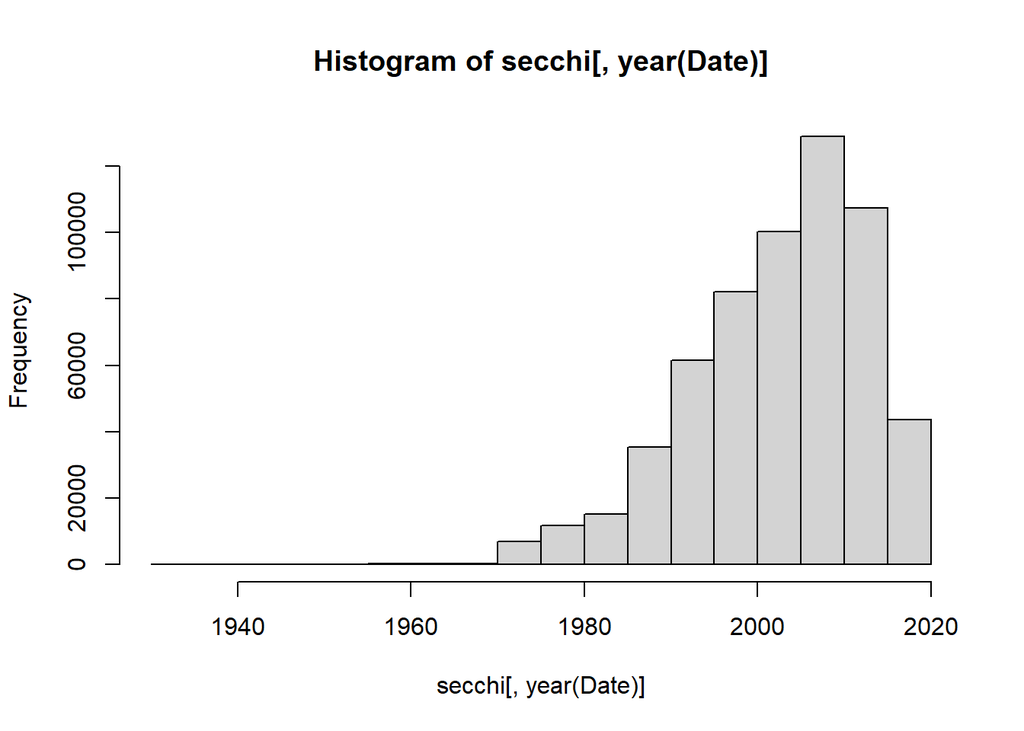

```r
  # number of observations
  hist(secchi[,year(Date)])
```

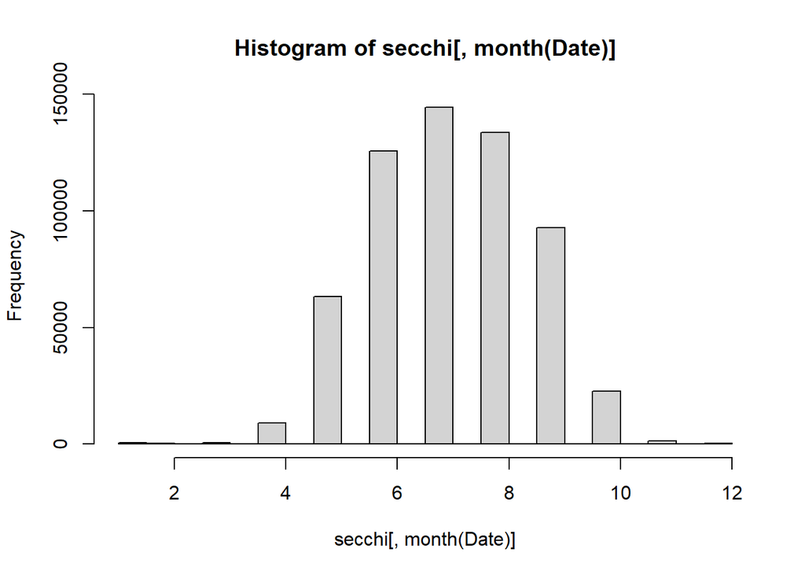

```r
  hist(secchi[,month(Date)])
```

```r
  secchi[,.N,Source]
```

```
##                  Source      N
##                  <char>  <int>
## 1:        Shallow Lakes   1124
## 2:                  PCA 576270
## 3:              DNRFish  10165
## 4: DNR Historical Files   4013
## 5:   ll_biologist_files   2320
```

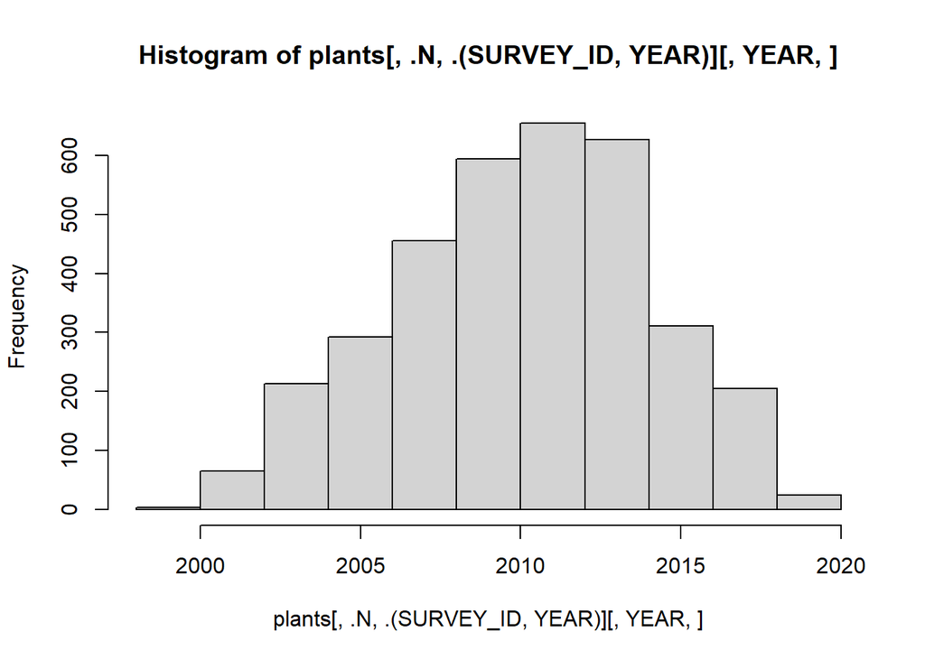

```r
  # and for the plants data?
  hist(plants[ ,.N , .(SURVEY_ID,YEAR) ][ , YEAR,])
```

```r
  #clean some data in prep for join
  secchi[, YEAR := year(Date)]
  secchi[, MONTH := month(Date) ]

  secchi[ , old_DOW := DOW]
  secchi[, DOW := as.integer(DOW)]
  secchi[ is.na(DOW) , old_DOW ]
```

```
## [1] "03IMP002" "24IMP001" "26IMP001" "R001-46G" "R001-46V" "R1-96-1"  "W0127601"
## [8] "W0655001"
```

```r
  #how many survey DOW's have a secchi for the lake (ever)?
  summary(plants[ , unique(DOW) , ]%in%secchi[ ,DOW ,])
```

```
##    Mode   FALSE    TRUE
## logical     160    1393
```

```r
  #how many surveys have a secchi for that year?
  summary(plants[ , .N ,.(DOW,YEAR) ][,paste(DOW,YEAR, sep = "_"),] %in% secchi[ ,paste(DOW,YEAR, sep = "_") ,])
```

```
##    Mode   FALSE    TRUE
## logical     614    2221
```

```r
  #how many surveys have a secchi for that month?
  summary(plants[ , .N ,.(DOW,YEAR,MONTH) ][,paste(paste(DOW,YEAR, sep = "_"),MONTH, sep = "_"),] %in%
            secchi[ ,paste(paste(DOW,YEAR, sep = "_"),MONTH, sep = "_")  ,])
```

```
##    Mode   FALSE    TRUE
## logical     843    2493
```

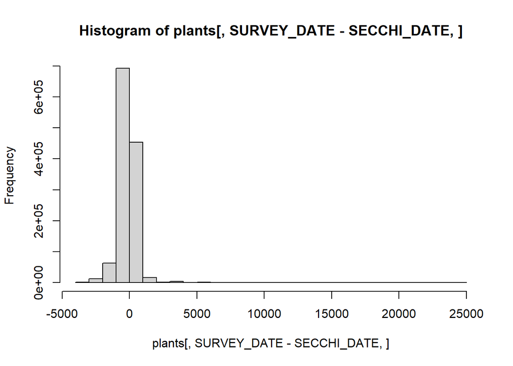

```r
  plants[ , date := SURVEY_DATE]



  #consolidate to the DOW-Date level
  secchi <- secchi[ , .("Secchi_m" = mean(Secchi_m))  , .(DOW, Date) ]
  secchi[ , SECCHI_DATE := Date]
  secchi <- secchi[!is.na(DOW)]

  plants <- secchi[plants,  , on = .(DOW, Date = date),  roll='nearest' ]

  #drop the Date field (now a dup of SURVEY_DATE)
  plants[ , Date := NULL]

  #how far apart are plant and secchi obs?
  hist(plants[,SURVEY_DATE-SECCHI_DATE,])
```

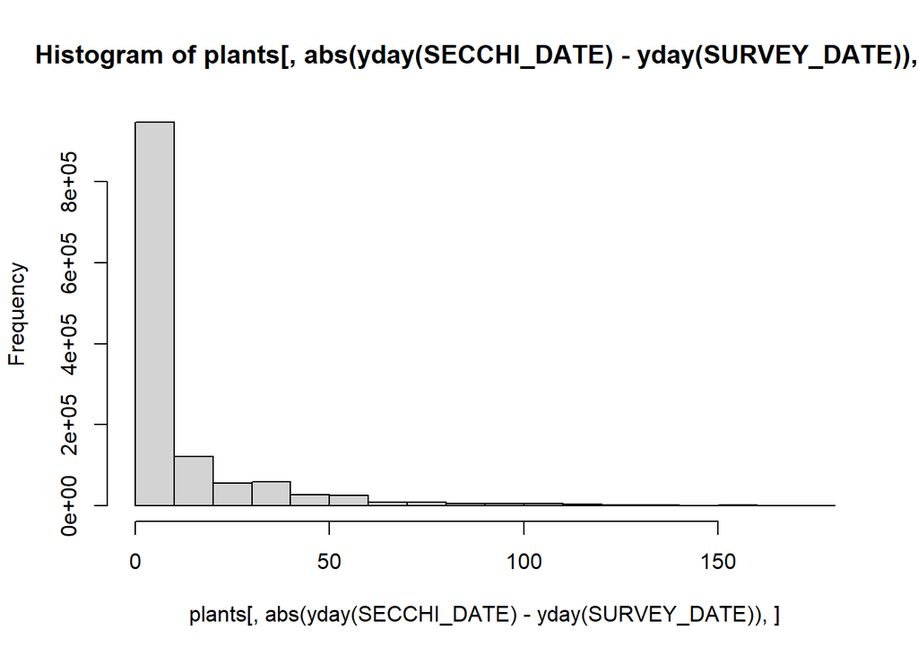

```r
  #keep only Secchi obs within a month (date+/-30d)
  hist(plants[ , abs(yday(SECCHI_DATE) - yday(SURVEY_DATE)), ])
```

```r
  plants[abs(yday(SECCHI_DATE) - yday(SURVEY_DATE))<30 &
           abs(year(SECCHI_DATE) - year(SURVEY_DATE))<1, SECCHI_m_ACCEPTED := Secchi_m ]

  #cleanup:
  rm(secchi)
```

### Avg Multiple Secchi measurements for each obs:

Assign a Secchi to each observation based on a few rules (EDIT to fit needs):

1. Use only Secchi from July-Sep
2. Create a mean for that time pd. for each lake-year of secchi data
3. Use summer means in same year (or +/- 1 year if no w/in year available)

```r
# an option for fuzzy temporal joins with averaging: (+/- 0 to 3yr)

  # #add month to secchi
  # secchi[ , MONTH := month(Date)]
  #
  # # Survey data (survey information columns from plants)
  # surveys <- plants[ , .N, .(DOW, SURVEY_DATE, YEAR, MONTH, SURVEY_ID)]
  #
  # # Joining secchi and surveys tables
  # surveys.secchi <- merge(surveys, secchi, by.x = "DOW", by.y = "DOW", allow.cartesian=TRUE)
  #
  # # Subsetting to summer secchi readings
  # surveys.secchi.summer <- surveys.secchi[MONTH.y %in% 7:9]
  #
  # # Same-year matches
  # surveys.secchi.summer.sameYr <- surveys.secchi.summer[YEAR.x == YEAR.y]
  #
  # # +/- 1-year matches
  # surveys.secchi.summer.within1Yr <- surveys.secchi.summer[YEAR.x %between% list(YEAR.y-1, YEAR.y+1)]
  #
  # # +/- 2-year matches
  # surveys.secchi.summer.within2Yr <- surveys.secchi.summer[YEAR.x %between% list(YEAR.y-2, YEAR.y+2)]
  #
  # # +/- 3-year matches
  # surveys.secchi.summer.within3Yr <- surveys.secchi.summer[YEAR.x %between% list(YEAR.y-3, YEAR.y+3)]
  #
  # matching.summ <-
  #   data.frame(Year.diff = c(0, 1, 2, 3),
  #              Matched.surveys = c(length(unique(surveys.secchi.summer.sameYr$SURVEY_ID)),
  #                                  length(unique(surveys.secchi.summer.within1Yr$SURVEY_ID)),
  #                                  length(unique(surveys.secchi.summer.within2Yr$SURVEY_ID)),
  #                                  length(unique(surveys.secchi.summer.within3Yr$SURVEY_ID))),
  #              Total.surveys = dim(surveys)[1]
  #   )
  #
  # (matching.summ <- transform(matching.summ, Prop.matched = round(Matched.surveys/Total.surveys, digits = 3)))
  #
  #
  # # choose a timeframe for join
  # # Secchi data to use: +/- 1-year matches w/ multiple secchi readings averaged
  # surveys.secchi.final <- surveys.secchi.summer.within1Yr
  # surveys.secchi.final[, Source := NULL]
  # setnames(surveys.secchi.final, old = c("YEAR.x", "YEAR.y", "MONTH.x", "Date", "MONTH.y"),
  #          new = c("YEAR.SURVEY", "YEAR.SECCHI", "MONTH.SURVEY", "DATE.SECCHI", "MONTH.SECCHI"), skip_absent=TRUE)
  #
  #
  # # calculate metrics for selected data
  #
  # # calc useable values and sum stats from each secchi set used by each survey linking to them
  # surveys.secchi.final <- surveys.secchi.final[, .(Secchi_m.mean=mean(Secchi_m), YEAR.SECCHI.mean=mean(YEAR.SECCHI), MONTH.SECCHI.mean=mean(MONTH.SECCHI),
  #                                                  Secchi_m.min=min(Secchi_m), YEAR.SECCHI.min=min(YEAR.SECCHI), MONTH.SECCHI.min=min(MONTH.SECCHI),
  #                                                  Secchi_m.max=max(Secchi_m), YEAR.SECCHI.max=max(YEAR.SECCHI), MONTH.SECCHI.max=max(MONTH.SECCHI),
  #                                                  Secchi_m.sd=sd(Secchi_m), Secchi_m.length=length(Secchi_m)),
  #                                              .(DOW, SURVEY_DATE, YEAR.SURVEY, MONTH.SURVEY, SURVEY_ID)]
  # surveys.secchi.final[, Secchi_m.se := Secchi_m.sd/sqrt(Secchi_m.sd)]
  # surveys.secchi.final[Secchi_m.se == "NaN", Secchi_m.se := 0]
  #
  # surveys.secchi.final[, .(Secchi_m.length) ]
  # surveys.secchi.final[, .(Secchi_m.sd) ]
  #
  #
  #
  # # link these to the plants dataset
  #
  # # merge by lake and date
  # plants <- merge(plants,surveys.secchi.final, by = c("SURVEY_ID","DOW", "SURVEY_DATE"), all.x = T)
  #
  # #cleanup intermediate products:
  #
  # rm(secchi,surveys,surveys.secchi, surveys.secchi.summer, surveys.secchi.summer.sameYr, surveys.secchi.final, surveys.secchi.summer.within1Yr, surveys.secchi.summer.within2Yr, surveys.secchi.summer.within3Yr, matching.summ)
  #
```

### Calculate a stat of light availability at the point level

```r
  # calculate point level light avail
  plants[ , proplight := exp(-(log(10)/SECCHI_m_ACCEPTED)*(DEPTH_FT/3.2804)) ]
  nrow(plants[!is.na(proplight) , .N , POINT_ID])/ #how many points can we do this for?
  nrow(plants[, .N , POINT_ID])#out of total n points
```

```
## [1] 0.7819176
```

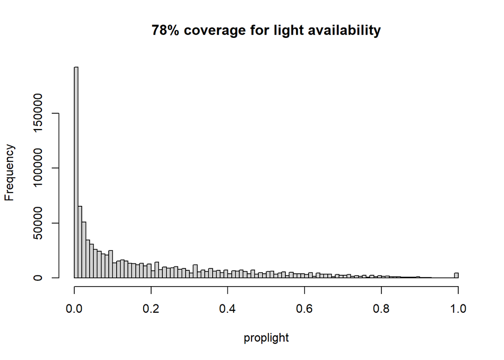

[output not shown]

[output cut: 47 more lines]

```r
  plants[ ,hist(proplight, breaks = 100, main = "78% coverage for light availability")]
```

```r
# plant status information ------------------------------------------------

  # native diversity must exclude invasives/introduced species
  rte <- clean_names(rte)

  plants[ , unique(TAXON) , ][!(plants[ , unique(TAXON) , ] %in% c(rte[native_status == "I", mn_dnr_scientific_name],
                                     "Nitellopsis", "Typha glauca"))]
```

```
##   [1] "Ceratophyllum demersum"         "Vallisneria americana"
##   [3] "Drepanocladus"                  NA
##   [5] "Potamogeton robbinsii"          "Carex"
##   [7] "Equisetum"                      "Nuphar variegata"
##   [9] "Potentilla palustris"           "Sagittaria"
##  [11] "Sparganium (floating)"          "Nymphaea odorata"
##  [13] "Potamogeton zosteriformis"      "Zizania palustris"
##  [15] "Schoenoplectus acutus"          "Potamogeton praelongus"
##  [17] "Brasenia schreberi"             "Utricularia vulgaris"
##  [19] "Potamogeton natans"             "Myriophyllum sibiricum"
##  [21] "Pontederia cordata"             "Schoenoplectus subterminalis"
##  [23] "Potamogeton amplifolius"        "Eleocharis"
##  [25] "Nitella"                        "Najas flexilis"
##  [27] "Potamogeton illinoensis"        "Potamogeton gramineus"
##  [29] "Chara"                          "Utricularia intermedia"
```

[output cut: 98 more lines]

```r
  #we'll use this to select columns as we calculate diversty metrics!
  natcols <- plants[ , unique(TAXON) , ][!(plants[ , unique(TAXON) , ] %in% c(rte[native_status == "I", mn_dnr_scientific_name],
                                                                              "Nitellopsis", "Typha glauca"))]


# summarize plants dataset ---------------------------------------------------
```

## Review Data Summaries

```r
  str(plants) #what data formats?
```

```
## Classes 'data.table' and 'data.frame':   1278192 obs. of  48 variables:
##  $ DOW                 : int  1001600 1001600 1001600 1001600 1001600 1001600 1001600 1001600 1001600 1001600 ...
##  $ Secchi_m            : num  0.762 0.762 0.762 0.762 0.762 0.762 0.762 0.762 0.762 0.762 ...
##  $ SECCHI_DATE         : IDate, format: "2011-08-16" "2011-08-16" ...
##  $ SURVEY_ID           : int  1 1 1 1 1 1 1 1 1 1 ...
##  $ LAKE_NAME           : chr  "little prairie" "little prairie" "little prairie" "little prairie" ...
##  $ DATASOURCE          : chr  "Muthukrishnan Et al" "Muthukrishnan Et al" "Muthukrishnan Et al" "Muthukrishnan Et al" ...
##  $ SURVEY_DATE         : IDate, format: "2011-08-16" "2011-08-16" ...
##  $ STA_NBR_DATASOURCE  : chr  "1" "1" "10" "11" ...
##  $ DEPTH_FT            : num  3.8 3.8 2.5 5.8 6 6.8 7 6.8 7 6.2 ...
##  $ NO_VEG_FOUND        : logi  FALSE FALSE FALSE TRUE TRUE FALSE ...
##  $ REL_ABUND           : int  NA NA NA NA NA NA NA NA NA NA ...
##  $ WHOLE_RAKE_REL_ABUND: chr  NA NA NA NA ...
##  $ SUBSTRATE           : chr  "" "" "" "" ...
##  $ SURVEYOR            : chr  NA NA NA NA ...
```

[output cut: 35 more lines]

```r
  names(plants) #field names
```

```
##  [1] "DOW"                  "Secchi_m"             "SECCHI_DATE"
##  [4] "SURVEY_ID"            "LAKE_NAME"            "DATASOURCE"
##  [7] "SURVEY_DATE"          "STA_NBR_DATASOURCE"   "DEPTH_FT"
## [10] "NO_VEG_FOUND"         "REL_ABUND"            "WHOLE_RAKE_REL_ABUND"
## [13] "SUBSTRATE"            "SURVEYOR"             "TAXON"
## [16] "SURVEY_ID_DATASOURCE" "SAMPLE_NOTES"         "SURFACE_GROWTH"
## [19] "POINT_LVL_SECCHI"     "POINT_ID"             "OBS_ID"
## [22] "OLD_SURVEY_ID"        "DATESURVEYSTART"      "COHORT"
## [25] "DATEINFO"             "MONTH"                "DAY"
## [28] "YEAR"                 "SUBBASIN"             "INVENTORY_STAFF"
## [31] "INVENTORY_STAFFDATE"  "USEABLE"              "CLEANED"
## [34] "INDATABASE"           "INVENTORY_NOTES"      "SUBMISSION_STAFF"
## [37] "SUBMISSION_STAFFDATE" "SUBMISSION_NOTES"     "MULTIPARTSURVEY"
## [40] "SURVEY_FEEDBACK"      "SURVEY_DATASOURCE"    "RAKE_SCALE_USED"
## [43] "order_ID"             "Longitude"            "Latitude"
## [46] "REL_ABUND_CORRECTED"  "SECCHI_m_ACCEPTED"    "proplight"
```

```r
  plants[ , length(unique(SURVEY_ID)) , ] #how many surveys in all?
```

```
## [1] 3453
```

```r
  plants[ INDATABASE == T , length(unique(SURVEY_ID))] #how many surveys do we have the data in our db for?
```

```
## [1] 3196
```

```r
  plants[ , length((unique(DOW))) , ] #how many lake in all?
```

```
## [1] 1553
```

```r
  plants[ , length(unique(YEAR)) , ] #how many years of data?
```

```
## [1] 22
```

```r
  plants[ , length(unique(POINT_ID)),] #how samples pulled from the lake?
```

```
## [1] 372827
```

```r
  plants[!is.na(TAXON) , length(unique(OBS_ID))] # how many times was a plant identified in these data?
```

```
## [1] 594127
```

Lets see how many surveys (then number of points) we have been given by each contributor:

```r
  plants[ , unique(SURVEY_DATASOURCE) ,]
```

```
##  [1] "DNR Shallow Lakes"
##  [2] "Newman Lab University of Minnesota"
##  [3] "Minnehaha Creek Watershed District"
##  [4] "DNR Invasive Species Program"
##  [5] "DNR Fisheries"
##  [6] "Freshwater Scientific Services"
##  [7] "Blue Water Science"
##  [8] "Minneapolis Park & Recreation Board"
##  [9] "Barr Engineering"
## [10] "Three Rivers Park District"
## [11] "AIS Consulting Services"
## [12] "Ramsey County"
## [13] "Ramsey-Washington Metro Watershed District"
## [14] "Capitol Region Watershed District"
## [15] "Emmons & Olivier Resources, Inc."
## [16] "Endangered Resource Services, LLC"
## [17] "DNR Lakes and Rivers"
```

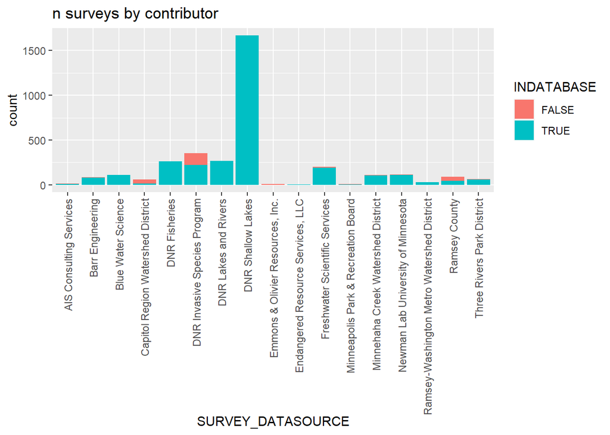

```r
  # survey contribution viz
  ggplot(plants[ , .N, .(SURVEY_ID, SURVEY_DATASOURCE, INDATABASE)], aes(SURVEY_DATASOURCE, fill = INDATABASE))+
    geom_bar(stat = "count", position = "stack" )+
    theme(axis.text.x = element_text(angle = 90, vjust = 0.5, hjust=1))+
    ggtitle(label = "n surveys by contributor")
```

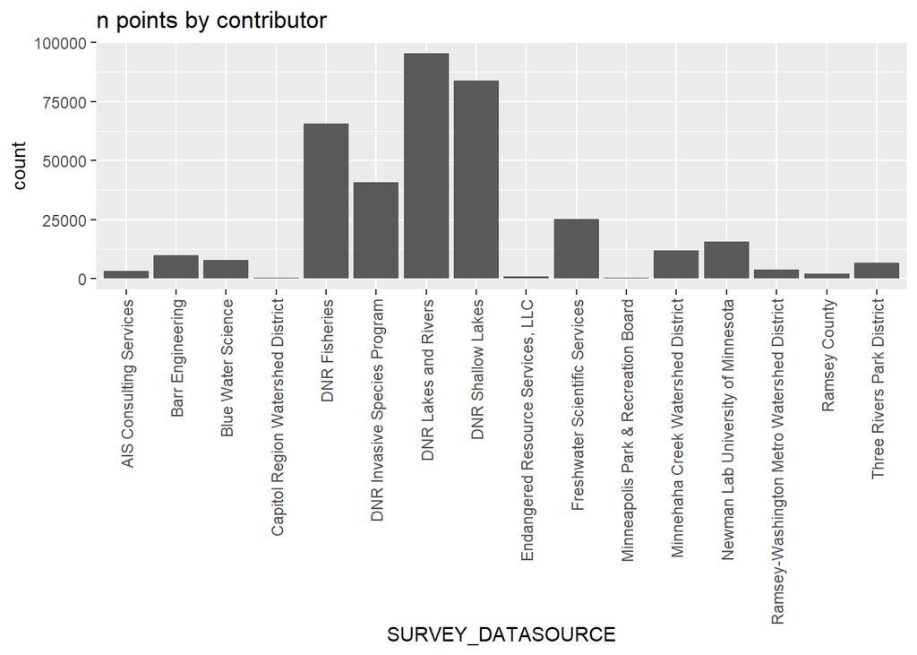

```r
  # point contributions
  ggplot(plants[INDATABASE==T , .N, .(POINT_ID, SURVEY_DATASOURCE, INDATABASE)], aes(SURVEY_DATASOURCE))+
    geom_bar(stat = "count", position = "stack" )+
    theme(axis.text.x = element_text(angle = 90, vjust = 0.5, hjust=1))+
    ggtitle(label = "n points by contributor")
```

The database has all the surveys we know exist for MN in it, including those for which we do not have the data. It is often useful to snip those no-data ones off right away to avoid running any calcs using all those rows w/o any species data.

```r
  missing_data_surveys <- plants[ INDATABASE == F]
  plants <- plants[INDATABASE == T]


# drop zeros --------------------------------------------------------------

  #' We dropped surveys with no depth data in an early cleaning step. This
  #' happened before we merged datasets from the MN DNR into the database, meaning
  #' that we've still got to do a purge of 0 and NA depths to be sure we've
  #' handled DNR and other collaborator data consistently:

  #any remaining points with depth == NA or 0? They need to be dropped to be consistent in the handling of all no depth sampled points (currently only MNDNR ):
  # plants[is.na(DEPTH_FT)|DEPTH_FT == 0 , ][ , .N , .(SURVEY_ID, DATASOURCE)]

  plants[is.na(DEPTH_FT), .N, .(SURVEY_ID, DATASOURCE)][, unique(DATASOURCE)] #these only still remain in the DNR data--thats because we did the DNR data merge after cleaning up the other data
```

```
## [1] "Muthukrishnan Et al"  "DNR Fisheries"        "DNR Lakes and Rivers"
```

```r
  sum(plants[ SURVEY_ID %in% plants[is.na(DEPTH_FT), .N, .(SURVEY_ID, DATASOURCE)][,SURVEY_ID], .N , .(SURVEY_ID, DATASOURCE)
  ][ , N]) #counts all points in those surveys
```

```
## [1] 57578
```

```r
  #drop them:
  plants <- plants[!is.na(DEPTH_FT) ]


# duplicated entries ------------------------------------------------------
```

It’s become aparrent to me that when we casted the data to long format in the survey collation project, we ended up with many cases of multiple “observations” of the same thing from within a single point. Here we clean up this issue. I found the cause of it by opening up the surveycollation project

```r
  #drop duplicated entries:
  names(plants)
```

```
##  [1] "DOW"                  "Secchi_m"             "SECCHI_DATE"
##  [4] "SURVEY_ID"            "LAKE_NAME"            "DATASOURCE"
##  [7] "SURVEY_DATE"          "STA_NBR_DATASOURCE"   "DEPTH_FT"
## [10] "NO_VEG_FOUND"         "REL_ABUND"            "WHOLE_RAKE_REL_ABUND"
## [13] "SUBSTRATE"            "SURVEYOR"             "TAXON"
## [16] "SURVEY_ID_DATASOURCE" "SAMPLE_NOTES"         "SURFACE_GROWTH"
## [19] "POINT_LVL_SECCHI"     "POINT_ID"             "OBS_ID"
## [22] "OLD_SURVEY_ID"        "DATESURVEYSTART"      "COHORT"
## [25] "DATEINFO"             "MONTH"                "DAY"
## [28] "YEAR"                 "SUBBASIN"             "INVENTORY_STAFF"
## [31] "INVENTORY_STAFFDATE"  "USEABLE"              "CLEANED"
## [34] "INDATABASE"           "INVENTORY_NOTES"      "SUBMISSION_STAFF"
## [37] "SUBMISSION_STAFFDATE" "SUBMISSION_NOTES"     "MULTIPARTSURVEY"
## [40] "SURVEY_FEEDBACK"      "SURVEY_DATASOURCE"    "RAKE_SCALE_USED"
## [43] "order_ID"             "Longitude"            "Latitude"
## [46] "REL_ABUND_CORRECTED"  "SECCHI_m_ACCEPTED"    "proplight"
```

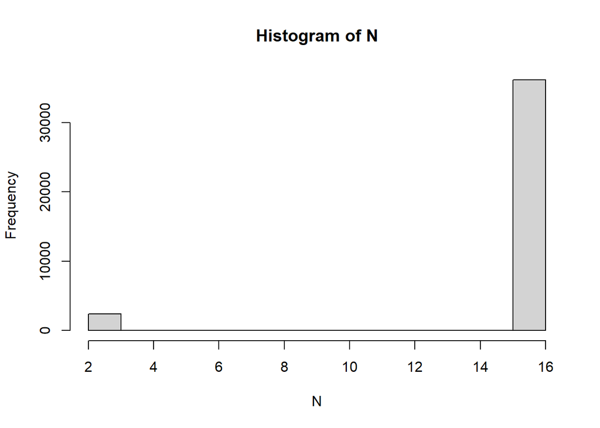

```
## $breaks
##  [1]  2  3  4  5  6  7  8  9 10 11 12 13 14 15 16
##
## $counts
##  [1]  2397    15     5     0     0     0     0     0     0     0     0     0
## [13]     0 36151
##
## $density
##  [1] 0.0621499689 0.0003889235 0.0001296412 0.0000000000 0.0000000000
##  [6] 0.0000000000 0.0000000000 0.0000000000 0.0000000000 0.0000000000
## [11] 0.0000000000 0.0000000000 0.0000000000 0.9373314665
##
## $mids
##  [1]  2.5  3.5  4.5  5.5  6.5  7.5  8.5  9.5 10.5 11.5 12.5 13.5 14.5 15.5
##
## $xname
## [1] "N"
##
## $equidist
## [1] TRUE
##
## attr(,"class")
## [1] "histogram"
```

```r
  plants[ , .N , .(SURVEY_ID,
                   POINT_ID ,
                   NO_VEG_FOUND ,
                   proplight ,
                   DEPTH_FT ,
                   SUBSTRATE ,
                   SURVEYOR, TAXON)  ][N>1 , hist(N) , ]
```

```r
  sum(duplicated(plants$OBS_ID))
```

```
## [1] 0
```

```r
  names(plants[ , .SD , .SDcols = !c("OBS_ID") ])
```

```
##  [1] "DOW"                  "Secchi_m"             "SECCHI_DATE"
##  [4] "SURVEY_ID"            "LAKE_NAME"            "DATASOURCE"
##  [7] "SURVEY_DATE"          "STA_NBR_DATASOURCE"   "DEPTH_FT"
## [10] "NO_VEG_FOUND"         "REL_ABUND"            "WHOLE_RAKE_REL_ABUND"
## [13] "SUBSTRATE"            "SURVEYOR"             "TAXON"
## [16] "SURVEY_ID_DATASOURCE" "SAMPLE_NOTES"         "SURFACE_GROWTH"
## [19] "POINT_LVL_SECCHI"     "POINT_ID"             "OLD_SURVEY_ID"
## [22] "DATESURVEYSTART"      "COHORT"               "DATEINFO"
## [25] "MONTH"                "DAY"                  "YEAR"
## [28] "SUBBASIN"             "INVENTORY_STAFF"      "INVENTORY_STAFFDATE"
## [31] "USEABLE"              "CLEANED"              "INDATABASE"
## [34] "INVENTORY_NOTES"      "SUBMISSION_STAFF"     "SUBMISSION_STAFFDATE"
## [37] "SUBMISSION_NOTES"     "MULTIPARTSURVEY"      "SURVEY_FEEDBACK"
## [40] "SURVEY_DATASOURCE"    "RAKE_SCALE_USED"      "order_ID"
## [43] "Longitude"            "Latitude"             "REL_ABUND_CORRECTED"
## [46] "SECCHI_m_ACCEPTED"    "proplight"
```

```r
  sum(duplicated(plants[ , .SD , .SDcols = !c("OBS_ID") ]))
```

```
## [1] 543494
```

```r
  plants <- plants[!duplicated(plants[ , .SD , .SDcols = !c("OBS_ID") ]) , , ]

  # still a bunch of dups leftover where we've got:
  # two abunds for one species or two of something for one species...
  # with a littel sleuthing, I can see that these are a whole mix of things. For
  # example, James Johnson submitted one survey with two samples for point 213...
  # the solution I'll use is to allow these obs to stay (assuming that both obs
  # are real, and the data entry resulted in a bad point ID for one of them).
  # because of this, when we agg to the point level, we'll have to choose an obs
  # to use that taxon. You'll see this play out in the species matrix
  # construction below:


  plants[ , .N , .(SURVEY_ID,
                   POINT_ID ,
                   NO_VEG_FOUND ,
                   proplight ,
                   DEPTH_FT ,
                   SUBSTRATE ,
                   SURVEYOR, TAXON)  ][N>1 , .N , ]
```

```
## [1] 1292
```

```r
  plants[ , .N , .(SURVEY_ID,
                   POINT_ID ,
                   NO_VEG_FOUND ,
                   proplight ,
                   DEPTH_FT ,
                   SUBSTRATE ,
                   SURVEYOR, TAXON)  ][N>1 , unique(POINT_ID) , ]
```

```
##   [1]  96591  96844 138942 138943 138944 138945 138948 138949 138950 138951
##  [11] 138952 138953 138954 138955 138956 138957 138958 138959 138960 138961
##  [21] 138962 138963 138964 138966 138967 138968 138969 138970 138971 138973
##  [31] 138974 138975 138976 138977 138979 138980 138981 138982 138983 138984
##  [41] 138987 138988 138989 138990 138991 138992 138993 138994 138995 138996
##  [51] 138997 138998 138999 139000 139001 139002 139003 139004 139005 139006
##  [61] 139007 139008 139009 139010 139012 139013 139014 139015 139016 139017
##  [71] 139018 139019 139020 139021 139022 139023 139024 139025 139026 139027
##  [81] 139028 139029 139030 139031 139032 139033 139034 139035 139036 139037
##  [91] 139038 139039 139040 139043 139044 139045 139046 139047 139050 139052
## [101] 139053 139054 139055 139056 139059 139063 139065 139066 139067 139068
## [111] 139070 139071 139072 139073 139074 139075 139076 139077 139080 139081
## [121] 139082 139083 139084 139085 139087 139088 139089 139090 139096 139097
## [131] 139098 139099 139101 139102 139103 139104 139105 139108 139109 139110
## [141] 139111 139112 139113 139114 139115 139116 139117 139118 139119 139121
```

[output cut: 51 more lines]

## The point observation dataset:

Now “plants” is only those surveys for which we were able to gather and collate the data. Below we organize these data 3 ways:

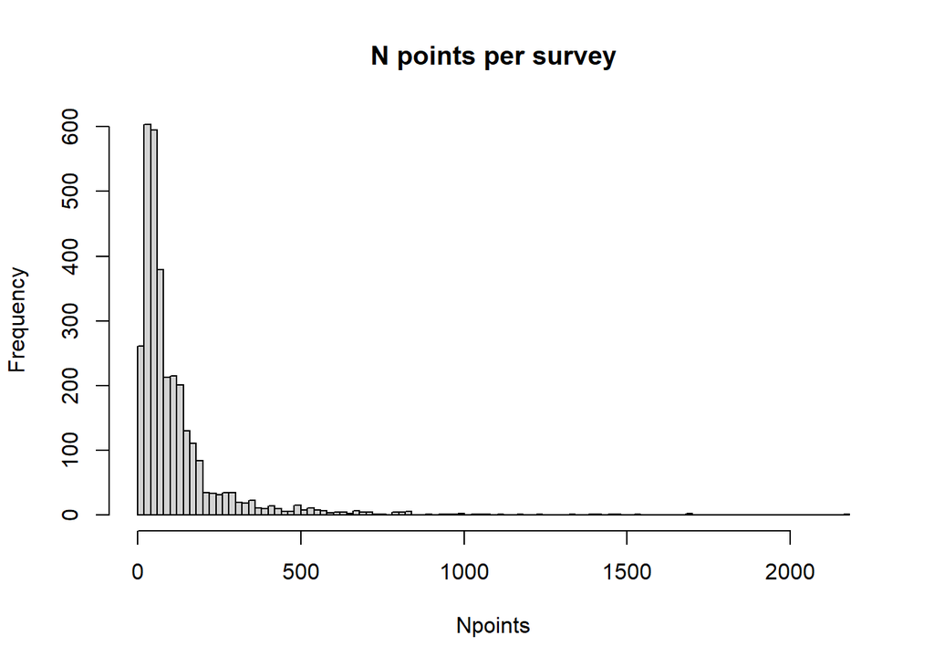

```r
  #how many surveys and how many points were sampled in each?
  hist(plants[ ,length(unique(POINT_ID)) , SURVEY_ID]$V1, breaks= 100, main = "N points per survey", xlab = "Npoints")
```

```r
  #how many unique TAXA?
  unique(plants$TAXON)
```

```
##   [1] "Ceratophyllum demersum"         "Vallisneria americana"
##   [3] "Drepanocladus"                  NA
##   [5] "Potamogeton robbinsii"          "Carex"
##   [7] "Equisetum"                      "Nuphar variegata"
##   [9] "Potentilla palustris"           "Sagittaria"
##  [11] "Sparganium (floating)"          "Nymphaea odorata"
##  [13] "Typha angustifolia"             "Potamogeton zosteriformis"
##  [15] "Zizania palustris"              "Schoenoplectus acutus"
##  [17] "Potamogeton praelongus"         "Brasenia schreberi"
##  [19] "Utricularia vulgaris"           "Potamogeton natans"
##  [21] "Myriophyllum sibiricum"         "Pontederia cordata"
##  [23] "Schoenoplectus subterminalis"   "Potamogeton amplifolius"
##  [25] "Eleocharis"                     "Nitella"
##  [27] "Najas flexilis"                 "Potamogeton illinoensis"
##  [29] "Potamogeton gramineus"          "Chara"
```

[output cut: 101 more lines]

```r
  # N taxa per survey:
  plants[ , .("Ntaxa" = length(unique(TAXON))) , SURVEY_ID] #if you want to name cols on the fly you need to wrap in .() which makes list from them
```

```
##       SURVEY_ID Ntaxa
##           <int> <int>
##    1:         1    13
##    2:         2    16
##    3:         3    25
##    4:         4    14
##    5:         5    16
##   ---
## 3190:      2041    36
## 3191:      2042    10
## 3192:      2043    14
## 3193:      2822    21
## 3194:      4336    19
```

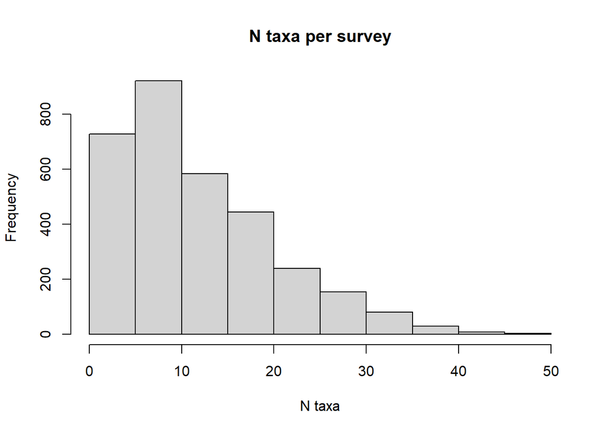

```r
  hist(plants[ , length(unique(TAXON)) , SURVEY_ID][ , V1], main = "N taxa per survey", xlab = "N taxa")
```

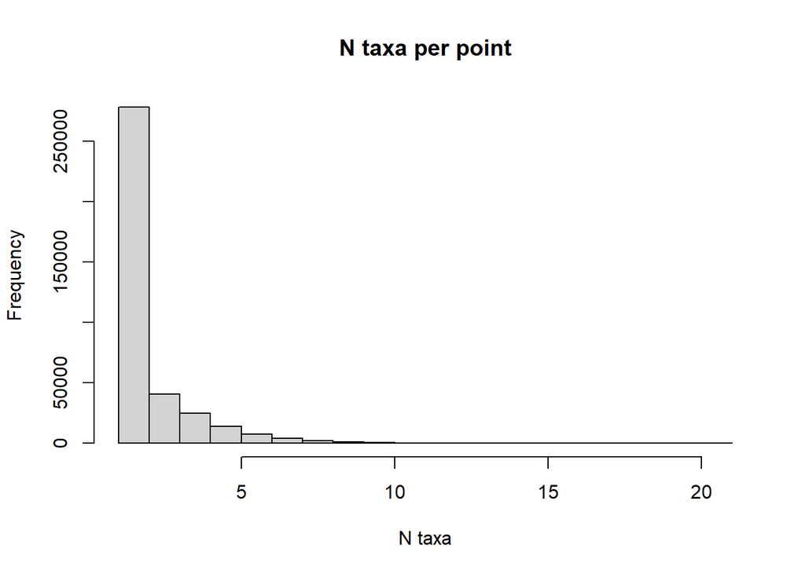

```r
  hist(plants[ , length(unique(TAXON)) , POINT_ID][ , V1], main = "N taxa per point", xlab = "N taxa")
```

```r
# point level p/a  -------------------------------------------------
  plants[ ,REL_ABUND]
```

[output not shown]

[output cut: 4153 more lines]

```r
  plants_occurrence_wide <- dcast(plants,
                                  SURVEY_ID+
                                    POINT_ID +
                                    NO_VEG_FOUND +
                                    proplight +
                                    DEPTH_FT +
                                    SUBSTRATE +
                                    SURVEYOR ~ TAXON, fun.aggregate = last,  value.var = "INDATABASE", fill = 0)

  #diversity metrics (only have richness with p/a, no "evenness", no "diversity"):
  point_natcols <- names(plants_occurrence_wide)[names(plants_occurrence_wide)%in%natcols]
  names(plants_occurrence_wide)
```

```
##   [1] "SURVEY_ID"                      "POINT_ID"
##   [3] "NO_VEG_FOUND"                   "proplight"
##   [5] "DEPTH_FT"                       "SUBSTRATE"
##   [7] "SURVEYOR"                       "NA"
##   [9] "Acorus"                         "Acorus americanus"
##  [11] "Alisma"                         "Alisma triviale"
##  [13] "Alnus"                          "Andromeda glaucophylla"
##  [15] "Andromeda polifolia"            "Asclepias incarnata"
##  [17] "Asteraceae"                     "Azolla mexicana"
##  [19] "Betula pumila"                  "Bidens"
##  [21] "Bidens beckii"                  "Bolboschoenus fluviatilis"
##  [23] "Bolboschoenus maritimus"        "Boltonia asteroides"
##  [25] "Brasenia schreberi"             "Butomus umbellatus"
##  [27] "Calamagrostis canadensis"       "Calla palustris"
##  [29] "Callitriche"                    "Caltha palustris"
```

[output cut: 105 more lines]

```r
  plants_occurrence_wide[ ,  richness := rowSums(.SD > 0), .SDcols = c(9:239) ]
  plants_occurrence_wide[ ,  nat_richness := rowSums(.SD > 0), .SDcols = point_natcols ]

  #bring all survey level variables back into the dataset
  #check join
  # nrow(plants[plants_occurrence_wide, on = .(POINT_ID, SURVEY_ID, NO_VEG_FOUND, proplight,DEPTH_FT,SUBSTRATE,SURVEYOR), mult = "last" , ])
  # names(plants[plants_occurrence_wide, on = .(POINT_ID, SURVEY_ID, NO_VEG_FOUND, proplight,DEPTH_FT,SUBSTRATE,SURVEYOR), mult = "last" , ])
  #
  plants_occurrence_wide <- plants[plants_occurrence_wide, on = .(POINT_ID, SURVEY_ID, NO_VEG_FOUND, proplight,DEPTH_FT,SUBSTRATE,SURVEYOR), mult = "last" , ]


  #and drop unneeded cols & those with loss of meaning through munging:
  plants_occurrence_wide[ , c("STA_NBR_DATASOURCE", "REL_ABUND", "REL_ABUND_CORRECTED", "WHOLE_RAKE_REL_ABUND", "SURVEY_ID_DATASOURCE", "SAMPLE_NOTES", "SURFACE_GROWTH", "POINT_LVL_SECCHI", "OLD_SURVEY_ID", "DATESURVEYSTART", "COHORT", "DATEINFO", "MONTH", "DAY", "YEAR", "INVENTORY_STAFF", "INVENTORY_STAFFDATE", "INVENTORY_NOTES", "USEABLE", "CLEANED", "INDATABASE", "SUBMISSION_STAFF", "SUBMISSION_STAFFDATE", "SUBMISSION_NOTES", "SURVEY_FEEDBACK", "DATASOURCE", "RAKE_SCALE_USED") := NULL , ]

  #check to make sure I didn't dump something critical:
  # sum(duplicated(plants_occurrence_wide))

# point level rake abund --------------------------------------------------

  plants_rakeabund_wide <- dcast(plants[!is.na(REL_ABUND_CORRECTED)], SURVEY_ID+
                                   POINT_ID +
                                   NO_VEG_FOUND +
                                   proplight +
                                   DEPTH_FT +
                                   SUBSTRATE +
                                   SURVEYOR ~ TAXON, value.var = c("REL_ABUND_CORRECTED"), fun.aggregate = last, fill = 0)

  #calculate diversity metrics for each rake throw
  rake_natcols <- names(plants_rakeabund_wide)[names(plants_rakeabund_wide)%in%natcols]
  names(plants_rakeabund_wide)
```

```
##   [1] "SURVEY_ID"                      "POINT_ID"
##   [3] "NO_VEG_FOUND"                   "proplight"
##   [5] "DEPTH_FT"                       "SUBSTRATE"
##   [7] "SURVEYOR"                       "Acorus americanus"
##   [9] "Bidens beckii"                  "Bolboschoenus fluviatilis"
##  [11] "Brasenia schreberi"             "Caltha palustris"
##  [13] "Carex"                          "Carex comosa"
##  [15] "Carex pellita"                  "Carex scoparia"
##  [17] "Ceratophyllum"                  "Ceratophyllum demersum"
##  [19] "Ceratophyllum echinatum"        "Chara"
##  [21] "Chara globularis"               "Characeae"
##  [23] "Cyperaceae"                     "Drepanocladus"
##  [25] "Eleocharis"                     "Eleocharis acicularis"
##  [27] "Eleocharis erythropoda"         "Eleocharis palustris"
##  [29] "Eleocharis robbinsii"           "Elodea"
```

[output cut: 58 more lines]

```r
  plants_rakeabund_wide[ , shannon_div := diversity(plants_rakeabund_wide[ , c(8:145)],index = "shannon") ]
  plants_rakeabund_wide[ , simpsons_div := diversity(plants_rakeabund_wide[ , c(8:145)],index = "invsimpson") ]
  plants_rakeabund_wide[ , shannon_div_nat := diversity(plants_rakeabund_wide[,.SD, .SDcols = rake_natcols],index = "shannon") ]
  plants_rakeabund_wide[ , simpsons_div_nat := diversity(plants_rakeabund_wide[,.SD, .SDcols = rake_natcols],index = "invsimpson") ]


  plants_rakeabund_wide[ ,  richness := rowSums(.SD > 0), .SDcols = c(8:145) ]
  plants_rakeabund_wide[ ,  nat_richness := rowSums(.SD > 0), .SDcols = rake_natcols ]

  summary(plants_rakeabund_wide$`Potamogeton crispus`)
```

```
##    Min. 1st Qu.  Median    Mean 3rd Qu.    Max.
##  0.0000  0.0000  0.0000  0.3931  1.0000  3.0000
```

```r
  #bring all survey level variables back into the dataset
  #check join
  # nrow(plants[plants_rakeabund_wide, on = .(POINT_ID, SURVEY_ID, NO_VEG_FOUND, proplight,DEPTH_FT,SUBSTRATE,SURVEYOR), mult = "last" , ])
  # names(plants[plants_rakeabund_wide, on = .(POINT_ID, SURVEY_ID, NO_VEG_FOUND, proplight,DEPTH_FT,SUBSTRATE,SURVEYOR), mult = "last" , ])
  #
  plants_rakeabund_wide <- plants[plants_rakeabund_wide, on = .(POINT_ID, SURVEY_ID, NO_VEG_FOUND, proplight,DEPTH_FT,SUBSTRATE,SURVEYOR), mult = "last" , ]


  #and drop unneeded cols & those with loss of meaning through munging:
  plants_rakeabund_wide[ , c("STA_NBR_DATASOURCE", "REL_ABUND", "REL_ABUND_CORRECTED", "WHOLE_RAKE_REL_ABUND", "SURVEY_ID_DATASOURCE", "SAMPLE_NOTES", "SURFACE_GROWTH", "POINT_LVL_SECCHI", "OLD_SURVEY_ID", "DATESURVEYSTART", "COHORT", "DATEINFO", "MONTH", "DAY", "YEAR", "INVENTORY_STAFF", "INVENTORY_STAFFDATE", "INVENTORY_NOTES", "USEABLE", "CLEANED", "INDATABASE", "SUBMISSION_STAFF", "SUBMISSION_STAFFDATE", "SUBMISSION_NOTES", "SURVEY_FEEDBACK", "DATASOURCE", "RAKE_SCALE_USED") := NULL , ]



  #cleanup:
  rm(point_natcols,rake_natcols)

  #CHOP ME OUT!
```

That is a good intro to the structure of these data. Some things to keep in mind: - Each row is an observation of a species at a point. - If there was no species observed, the row is a placeholder for that point, and that row will have NO_VEG_FOUND set to TRUE, but TAXON and density will be blank - If there are no data for a survey, that row is a placeholder for the survey, and all of the point-level data will be NAs

## Survey Level Data

```r
# survey level stats -------------------------------------------
  surveys <- plants[ , .(tot_n_samp = length(unique(POINT_ID)))  , SURVEY_ID ]

  #add richness to the surveys dataset
  surveys[  , taxa_richness := #take the "taxon count" and subtract one if the survey includes NAs (see next two lines)
              plants[ , length(unique(TAXON))   , SURVEY_ID ][ , V1]-# ("total richness", but counts NAs as a taxon) minus
              plants[ , ifelse(sum(is.na(TAXON))== 0, 0, 1), SURVEY_ID][,V1],]#  (each survey get a 0 if no NAs or a 1 if contains NA's)

  # extent of vegetation in survey (proportion vegetated)
  surveys <- merge(surveys,plants[!is.na(TAXON), .(n_points_vegetated=length(unique(POINT_ID))) , SURVEY_ID ], by = "SURVEY_ID", all.x = TRUE)[is.na(n_points_vegetated), n_points_vegetated := 0 ]
  surveys[ , prop_veg := n_points_vegetated/tot_n_samp ,]

  #create a plant observation matrix (species abund by survey)
  survey_species_matrix <- dcast(plants[!is.na(TAXON) , .("count" = length(unique(POINT_ID))) , .(SURVEY_ID,TAXON)], SURVEY_ID ~ TAXON, value.var = "count", fill = 0) #note that this line creates the matrix ONLY for surveys that had species obseravtions (~70 surveys had no species observed)

  #diversity indicies:
  # species names:
  natcols <- names(survey_species_matrix)[names(survey_species_matrix) %in% natcols]

  # total diversity
  survey_species_matrix[ , shannon_div := diversity(survey_species_matrix[,2:232],index = "shannon") ]
  survey_species_matrix[ , simpsons_div := diversity(survey_species_matrix[,2:232],index = "invsimpson") ]

  # native diversity
  survey_species_matrix[ , shannon_div_nat := diversity(survey_species_matrix[,.SD, .SDcols = natcols],index = "shannon") ]
  survey_species_matrix[ , simpsons_div_nat := diversity(survey_species_matrix[,.SD, .SDcols = natcols],index = "invsimpson") ]
  survey_species_matrix[simpsons_div_nat == Inf, simpsons_div_nat := 0]

  # native richness
  survey_species_matrix[ ,  nat_richness := rowSums(survey_species_matrix[ , .SD, .SDcols = natcols] > 0), ]

  # depth stats
  # depth surveyed stats:
  surveys <- surveys[plants[ !is.na(DEPTH_FT), .("max_depth_surveyed" = max(DEPTH_FT)) , SURVEY_ID], on = "SURVEY_ID" , ]
  surveys <- surveys[plants[ !is.na(DEPTH_FT), .("min_depth_surveyed" = min(DEPTH_FT)) , SURVEY_ID], on = "SURVEY_ID" , ]
  surveys <- surveys[plants[ !is.na(DEPTH_FT), .("mean_depth_surveyed" = mean(DEPTH_FT)) , SURVEY_ID], on = "SURVEY_ID" , ]
  surveys <- surveys[plants[ !is.na(DEPTH_FT), .("median_depth_surveyed" = median(DEPTH_FT)) , SURVEY_ID], on = "SURVEY_ID" , ]
  surveys <- surveys[plants[ !is.na(DEPTH_FT), .("IQR_depth_surveyed" = IQR(DEPTH_FT)) , SURVEY_ID], on = "SURVEY_ID" , ]

  #vegetated depths data
  #max depth vegetated:
  plants[ NO_VEG_FOUND == FALSE , .("max_depth_vegetated" = max(DEPTH_FT)) , SURVEY_ID]
```

```
##       SURVEY_ID max_depth_vegetated
##           <int>               <num>
##    1:         1                 7.0
##    2:         2                11.0
##    3:         3                 6.0
##    4:         4                 4.0
##    5:         5                 6.2
##   ---
## 3122:      2041                10.0
## 3123:      2042                13.0
## 3124:      2043                 8.0
## 3125:      2822                19.0
## 3126:      4336                 9.0
```

```r
  surveys <- merge( surveys , plants[ NO_VEG_FOUND == FALSE , .("max_depth_vegetated" = max(DEPTH_FT, na.rm = T)) , SURVEY_ID] , by = "SURVEY_ID" , all.x =TRUE )
  #other depth vegetated stats:
  surveys <- merge( surveys , plants[ NO_VEG_FOUND == FALSE , .("min_depth_vegetated" = min(DEPTH_FT, na.rm = T)) , SURVEY_ID], by = "SURVEY_ID" , all.x =TRUE )
  surveys <- merge( surveys , plants[ NO_VEG_FOUND == FALSE , .("mean_depth_vegetated" = mean(DEPTH_FT, na.rm = T)) , SURVEY_ID], by = "SURVEY_ID" , all.x =TRUE )
  surveys <- merge( surveys , plants[ NO_VEG_FOUND == FALSE , .("median_depth_vegetated" = median(DEPTH_FT, na.rm = T)) , SURVEY_ID], by = "SURVEY_ID" , all.x =TRUE )
  surveys <- merge( surveys , plants[ NO_VEG_FOUND == FALSE , .("IQR_depth_vegetated" = IQR(DEPTH_FT, na.rm = T)) , SURVEY_ID], by = "SURVEY_ID" , all.x =TRUE )


  # species matrix into survey data
  #species matrix for surveys
  surveys <- merge(surveys, survey_species_matrix, by = "SURVEY_ID", all.x = T)
  f_dowle3natozeros(surveys, names(survey_species_matrix)) #the merge incorrectly assigns NAs for non obs... here we replace those with 0s
  # check work:
  # summary(surveys[,1:17])

  #append survey data (basic data from plants db) to these
  # names(plants)
  surveys <- merge(plants[ , .("nobs" = .N) , .(SURVEY_ID, DATASOURCE, LAKE_NAME, DOW, DATESURVEYSTART, SUBBASIN, MULTIPARTSURVEY, order_ID) ],surveys,  by = "SURVEY_ID")
  # summary(surveys)
  names(surveys) <- gsub(" ", "_", gsub( "\\(", "_", gsub( "\\)", "_", names(surveys))))

  #get dates squared away in surveys
  surveys[ ,sort(unique(DATESURVEYSTART)),]
```

```
##    [1] "1/1/2009"   "1/1/2012"   "10/10/2013" "10/11/2012" "10/13/2014"
##    [6] "10/16/2008" "10/24/2007" "10/24/2014" "10/25/2007" "10/3/2007"
##   [11] "10/3/2012"  "10/30/2012" "10/4/2011"  "10/5/2004"  "10/8/2008"
##   [16] "3/21/2012"  "3/25/2009"  "3/26/2012"  "3/30/2010"  "3/31/2010"
##   [21] "4/1/2011"   "4/13/2009"  "4/13/2015"  "4/14/2008"  "4/14/2011"
##   [26] "4/16/2009"  "4/16/2010"  "4/17/2009"  "4/18/2007"  "4/18/2009"
##   [31] "4/2/2010"   "4/2/2012"   "4/22/2008"  "4/22/2017"  "4/23/2007"
##   [36] "4/23/2015"  "4/23/2017"  "4/24/2007"  "4/25/2006"  "4/25/2011"
##   [41] "4/25/2017"  "4/26/2006"  "4/27/2011"  "4/27/2017"  "4/28/2008"
##   [46] "4/28/2010"  "4/28/2015"  "4/28/2017"  "4/29/2008"  "4/29/2009"
##   [51] "4/29/2010"  "4/29/2011"  "4/29/2012"  "4/30/2007"  "4/30/2009"
##   [56] "4/30/2010"  "4/30/2012"  "4/30/2013"  "4/30/2016"  "4/4/2012"
##   [61] "4/4/2016"   "4/5/2010"   "4/5/2012"   "4/7/2009"   "4/9/2010"
##   [66] "5/1/2007"   "5/1/2012"   "5/1/2014"   "5/1/2016"   "5/10/2007"
##   [71] "5/10/2009"  "5/10/2012"  "5/10/2015"  "5/10/2016"  "5/11/2007"
```

[output cut: 226 more lines]

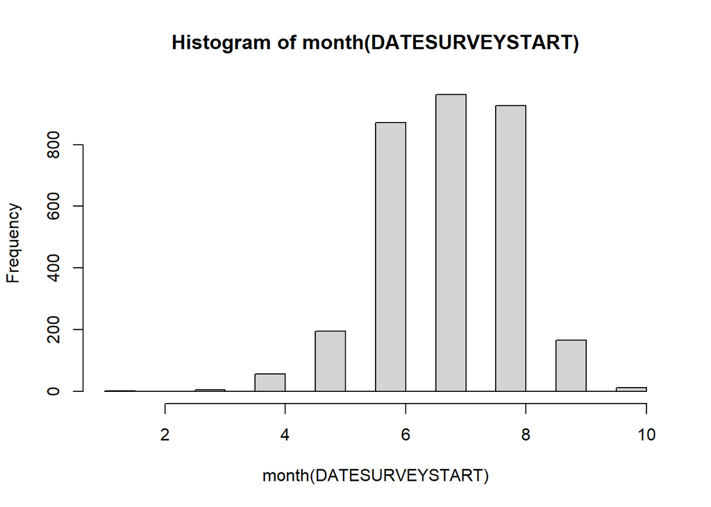

```
## $breaks
##  [1]  1.0  1.5  2.0  2.5  3.0  3.5  4.0  4.5  5.0  5.5  6.0  6.5  7.0  7.5  8.0
## [16]  8.5  9.0  9.5 10.0
##
## $counts
##  [1]   2   0   0   5   0  56   0 195   0 871   0 961   0 925   0 166   0  13
##
## $density
##  [1] 0.001252348 0.000000000 0.000000000 0.003130870 0.000000000 0.035065748
##  [7] 0.000000000 0.122103945 0.000000000 0.545397621 0.000000000 0.601753287
## [13] 0.000000000 0.579211021 0.000000000 0.103944897 0.000000000 0.008140263
##
## $mids
##  [1] 1.25 1.75 2.25 2.75 3.25 3.75 4.25 4.75 5.25 5.75 6.25 6.75 7.25 7.75 8.25
## [16] 8.75 9.25 9.75
##
## $xname
## [1] "month(DATESURVEYSTART)"
##
## $equidist
## [1] TRUE
##
## attr(,"class")
## [1] "histogram"
```

```r
  surveys[ , DATESURVEYSTART := as.Date(DATESURVEYSTART, format = "%m/%d/%Y" ),]
  surveys[ , hist(month(DATESURVEYSTART)) ,]
```

```r
  surveys[ , year := year(DATESURVEYSTART) , ]


  # secchi data metrics
  # rescue the secchi data from the plants db for these surveys
  surveys <- merge(surveys,plants[ , .("Secchi.m" = mean(Secchi_m)), SURVEY_ID], by.x = "SURVEY_ID", by.y = "SURVEY_ID")

#merge in the geodata + lake data
  surveys <- pwi_l[surveys, on = .(order_ID), mult = "first" ]


# species pools -----------------------------------------------------------
```

We have super awesome species pool data because we’ve got species abunds across multiple scales: From the smallest (point– plants_rakeabund_wide or plants_occurrence_wide) scale we have a species abundance matrix that can be treated as a product of the species pool above it (whole survey/lake), which we also have an abundance matrix for! We can also move up to the landscape scale, building species abundance matricies by aggregating these next-lower-scale data.

For example, we can do as described above (compressing matricies to richness for viz) and aggregate to the HUC-8 watershed level.

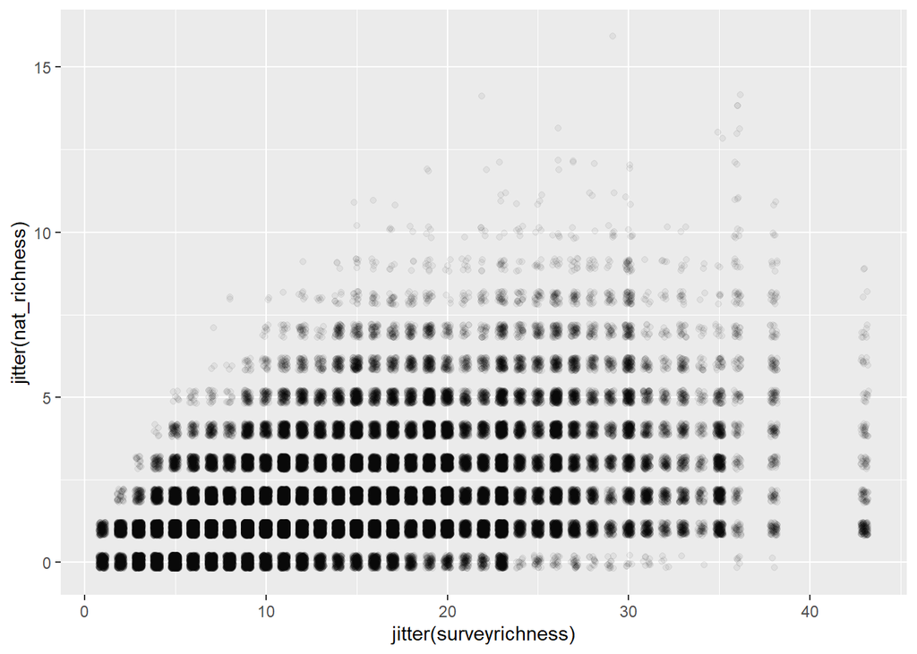

```r
  #first add the lake level richness from each survey to the point rake abund data
  plants_rakeabund_wide[ , surveyrichness := surveys[match(plants_rakeabund_wide[ ,SURVEY_ID ,], surveys[, SURVEY_ID, ]), taxa_richness] ,]

    ggplot( data = plants_rakeabund_wide,
            aes(jitter(surveyrichness), jitter(nat_richness)))+
      geom_point(alpha = .05)
```

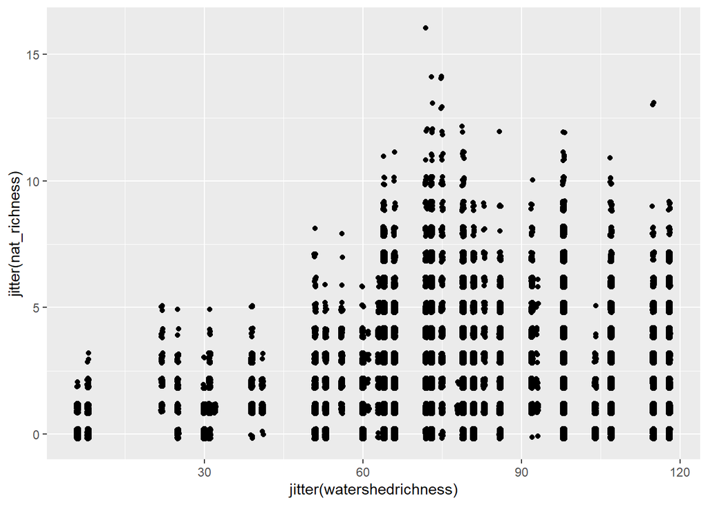

```r
  # now we need to create a watershed level species matrix:
  #check keys
  # pwi_l$order_ID
  # plants$order_ID

  plants[ , watershed := pwi_l[match(plants[ , order_ID ,],pwi_l[ , order_ID ,]), major , ],]

  # plants[ , length(unique(POINT_ID)) , watershed]

  watersheds <- plants[ , .("n_points" = length(unique(POINT_ID))) , watershed]

  watersheds <- merge(watersheds,
        plants[!is.na(TAXON) , .("n_species" = length(unique(TAXON))) , watershed],
        by = "watershed",
        all.x = T)


  watershed_occurrence_wide <- dcast(plants, watershed ~ TAXON, value.var = "INDATABASE", fun.aggregate = sum, fill = 0)

  watershed_occurrence_wide <- merge(watersheds,
                      watershed_occurrence_wide,
                      by = "watershed",
                      all.x = T)

  plants_rakeabund_wide[ , watershed := plants[match(plants_rakeabund_wide[ ,SURVEY_ID ,], plants[, SURVEY_ID, ]), watershed] ,]

  plants_rakeabund_wide[ , watershedrichness := watershed_occurrence_wide[match(plants_rakeabund_wide[ ,watershed ,],    watershed_occurrence_wide[, watershed, ]), n_species] ,]

  # watershed richness as the predictor:

  ggplot( data = plants_rakeabund_wide,
          aes(jitter(watershedrichness), jitter(nat_richness)))+
    geom_point()
```

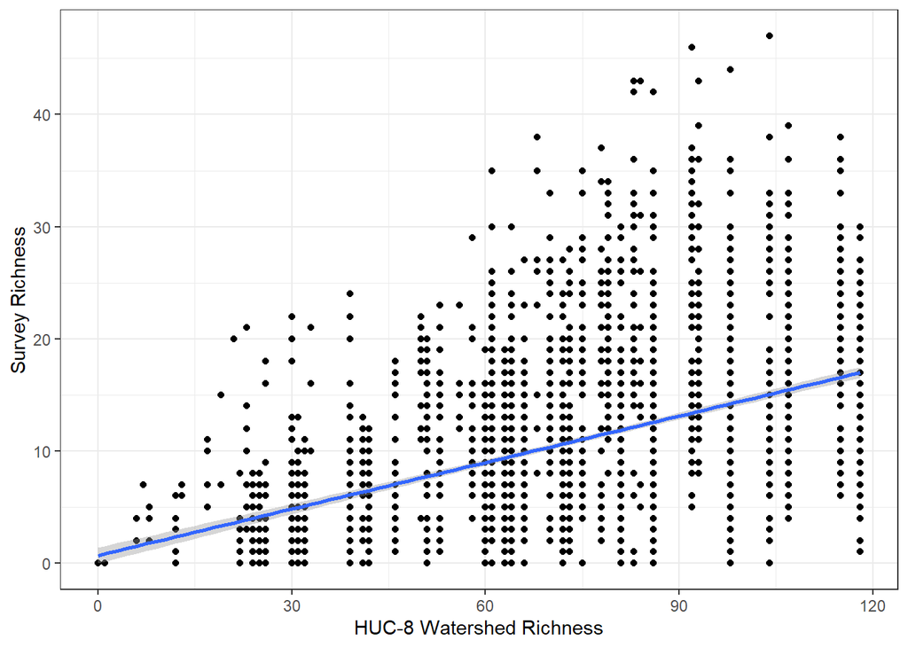

```r
  surveys[ , watershed := plants[match(surveys[ , SURVEY_ID ,], plants[, SURVEY_ID, ]), watershed] ,]
  surveys[ , watershedrichness := watershed_occurrence_wide[match(surveys[ ,watershed ,], watershed_occurrence_wide[, watershed, ]), n_species] ,]

  surveys[is.na(watershedrichness), watershedrichness := 0]

  ggplot( data = surveys,
          aes(watershedrichness, nat_richness))+
    geom_point()+
    geom_smooth(method = "lm")+
    ylab("Survey Richness")+
    xlab("HUC-8 Watershed Richness")+
    theme_bw()
```